# SR_04_RLTD_ORG_CORP_ADDR_L1

Related organization street address line 1 · Text report

## Overview

**Description**

Address Foreign - AddressLine1

**Table**

`SR-P04-T01-ID-RLTD-ORGS-TAXABLE-CORPORATION` (many)

**Location code**

`SCHED-R-PART-04-COL-A`

**Family**

`SCHED-R-PART-04-COL-A` · siblings: SR_04_RLTD_ORG_CORP_ADDR_CITY, SR_04_RLTD_ORG_CORP_ADDR_CNTR, SR_04_RLTD_ORG_CORP_ADDR_L2, SR_04_RLTD_ORG_CORP_ADDR_STATE, SR_04_RLTD_ORG_CORP_ADDR_ZIP, SR_04_RLTD_ORG_CORP_EIN

**Data type**

text (xsd: StreetAddressType)

**Scope**

PC

**Status**

unreviewed

6

xpaths mapped (6 observed)

273,361

filings with a value

2009–2024

tax years observed

1

open flags (1 errors)

## Flags

| Severity | Flag | Xpath | Detail |
| --- | --- | --- | --- |
| ⚠ error | `COLLISION` | IRS990ScheduleR/IdRelatedOrgTxblCorpTrGrp/ForeignAddress/AddressLine1Txt | 30343 filings contain 2+ of its xpaths; most common set: /Return/ReturnData/IRS990ScheduleR/IdRelatedOrgTxblCorpTrGrp/ForeignAddress/AddressLine1Txt ; /Return/ReturnData/IRS990ScheduleR/IdRelatedOrgTx… |

## Xpaths

All mapped xpaths (under /Return/ReturnData or /Return/ReturnHeader), oldest first. Charts label each series by its xpath.

| Xpath | Form | Chart label | First year | Last year | Versions | Filings | Repeats in |
| --- | --- | --- | --- | --- | --- | --- | --- |
| IRS990ScheduleR/Form990ScheduleRPartIV/AddressUS/AddressLine1 | Sched R | …90ScheduleR/Form990ScheduleRPartIV/AddressUS/AddressLine1 | 2009 | 2012 | 17 | 40,944 | 51.8% |
| IRS990ScheduleR/Form990ScheduleRPartIV/AddressForeign/AddressLine1 | Sched R | …eduleR/Form990ScheduleRPartIV/AddressForeign/AddressLine1 | 2009 | 2012 | 14 | 5,513 | 31.8% |
| IRS990ScheduleR/IdRelatedOrgTxblCorpTrGrp/USAddress/AddressLine1 | Sched R | …cheduleR/IdRelatedOrgTxblCorpTrGrp/USAddress/AddressLine1 | 2013 | 2013 | 3 | 14,114 | 50.3% |
| IRS990ScheduleR/IdRelatedOrgTxblCorpTrGrp/ForeignAddress/AddressLine1 | Sched R | …leR/IdRelatedOrgTxblCorpTrGrp/ForeignAddress/AddressLine1 | 2013 | 2013 | 3 | 2,008 | 37.0% |
| IRS990ScheduleR/IdRelatedOrgTxblCorpTrGrp/USAddress/AddressLine1Txt | Sched R | …duleR/IdRelatedOrgTxblCorpTrGrp/USAddress/AddressLine1Txt | 2014 | 2024 | 34 | 182,343 | 51.0% |
| IRS990ScheduleR/IdRelatedOrgTxblCorpTrGrp/ForeignAddress/AddressLine1Txt | Sched R | …/IdRelatedOrgTxblCorpTrGrp/ForeignAddress/AddressLine1Txt | 2014 | 2024 | 33 | 28,439 | 38.8% |

## Coverage

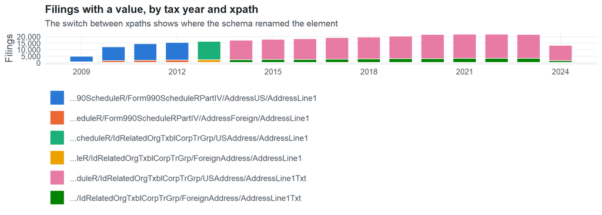

**Table view**

Table view: filings by tax year and series

| Tax year | …90ScheduleR/Form990ScheduleRPartIV/AddressUS/AddressLine1 | …eduleR/Form990ScheduleRPartIV/AddressForeign/AddressLine1 | …cheduleR/IdRelatedOrgTxblCorpTrGrp/USAddress/AddressLine1 | …leR/IdRelatedOrgTxblCorpTrGrp/ForeignAddress/AddressLine1 | …duleR/IdRelatedOrgTxblCorpTrGrp/USAddress/AddressLine1Txt | …/IdRelatedOrgTxblCorpTrGrp/ForeignAddress/AddressLine1Txt |
| --- | --- | --- | --- | --- | --- | --- |
| 2009 | 4,167 | 592 | 0 | 0 | 0 | 0 |
| 2010 | 10,720 | 1,363 | 0 | 0 | 0 | 0 |
| 2011 | 12,659 | 1,690 | 0 | 0 | 0 | 0 |
| 2012 | 13,398 | 1,868 | 0 | 0 | 0 | 0 |
| 2013 | 0 | 0 | 14,114 | 2,008 | 0 | 0 |
| 2014 | 0 | 0 | 0 | 0 | 14,930 | 2,055 |
| 2015 | 0 | 0 | 0 | 0 | 15,444 | 2,200 |
| 2016 | 0 | 0 | 0 | 0 | 15,775 | 2,315 |
| 2017 | 0 | 0 | 0 | 0 | 16,561 | 2,410 |
| 2018 | 0 | 0 | 0 | 0 | 16,741 | 2,734 |
| 2019 | 0 | 0 | 0 | 0 | 17,305 | 2,895 |
| 2020 | 0 | 0 | 0 | 0 | 18,341 | 3,032 |
| 2021 | 0 | 0 | 0 | 0 | 18,550 | 3,114 |
| 2022 | 0 | 0 | 0 | 0 | 18,640 | 3,131 |
| 2023 | 0 | 0 | 0 | 0 | 18,431 | 3,102 |
| 2024 | 0 | 0 | 0 | 0 | 11,625 | 1,451 |

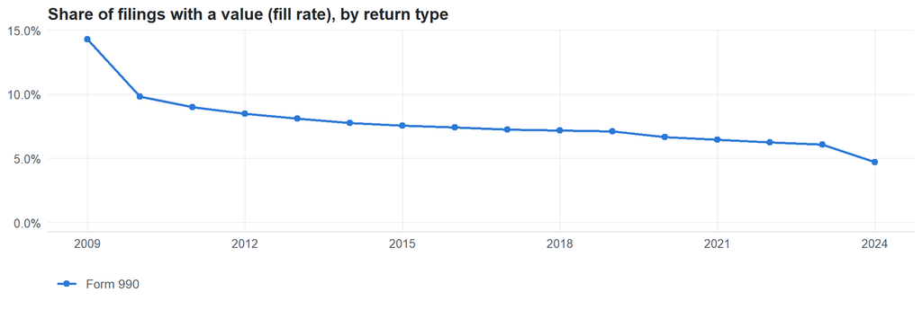

**Table view**

Table view: fill rate

| Tax year | Return type | Filings | All filings | Fill rate |
| --- | --- | --- | --- | --- |
| 2009 | Form 990 | 4,759 | 33,311 | 14.29% |
| 2010 | Form 990 | 12,083 | 123,025 | 9.82% |
| 2011 | Form 990 | 14,349 | 159,504 | 9.00% |
| 2012 | Form 990 | 15,266 | 179,688 | 8.50% |
| 2013 | Form 990 | 16,122 | 198,855 | 8.11% |
| 2014 | Form 990 | 16,985 | 218,619 | 7.77% |
| 2015 | Form 990 | 17,644 | 233,519 | 7.56% |
| 2016 | Form 990 | 18,090 | 243,903 | 7.42% |
| 2017 | Form 990 | 18,971 | 261,612 | 7.25% |
| 2018 | Form 990 | 19,475 | 271,442 | 7.17% |
| 2019 | Form 990 | 20,200 | 283,694 | 7.12% |
| 2020 | Form 990 | 21,373 | 320,342 | 6.67% |
| 2021 | Form 990 | 21,664 | 336,480 | 6.44% |
| 2022 | Form 990 | 21,771 | 349,055 | 6.24% |
| 2023 | Form 990 | 21,533 | 354,768 | 6.07% |
| 2024 | Form 990 | 13,076 | 277,298 | 4.72% |

## Repeating groups

Table cardinality in the concordance: **many**. 6 of 6 observed xpaths repeat within a filing.

Repeating element each xpath was observed in (from the raw indexed xpath)

| Xpath | Repeating element | Filings (summed over years) |
| --- | --- | --- |
| IRS990ScheduleR/Form990ScheduleRPartIV/AddressForeign/AddressLine1 | (none) | 474 |
| IRS990ScheduleR/Form990ScheduleRPartIV/AddressForeign/AddressLine1 | IRS990ScheduleR/Form990ScheduleRPartIV | 5039 |
| IRS990ScheduleR/Form990ScheduleRPartIV/AddressUS/AddressLine1 | (none) | 18843 |
| IRS990ScheduleR/Form990ScheduleRPartIV/AddressUS/AddressLine1 | IRS990ScheduleR/Form990ScheduleRPartIV | 22101 |
| IRS990ScheduleR/IdRelatedOrgTxblCorpTrGrp/ForeignAddress/AddressLine1 | (none) | 183 |
| IRS990ScheduleR/IdRelatedOrgTxblCorpTrGrp/ForeignAddress/AddressLine1 | IRS990ScheduleR/IdRelatedOrgTxblCorpTrGrp | 1825 |
| IRS990ScheduleR/IdRelatedOrgTxblCorpTrGrp/USAddress/AddressLine1 | (none) | 6705 |
| IRS990ScheduleR/IdRelatedOrgTxblCorpTrGrp/USAddress/AddressLine1 | IRS990ScheduleR/IdRelatedOrgTxblCorpTrGrp | 7409 |
| IRS990ScheduleR/IdRelatedOrgTxblCorpTrGrp/ForeignAddress/AddressLine1Txt | (none) | 2806 |
| IRS990ScheduleR/IdRelatedOrgTxblCorpTrGrp/ForeignAddress/AddressLine1Txt | IRS990ScheduleR/IdRelatedOrgTxblCorpTrGrp | 25633 |
| IRS990ScheduleR/IdRelatedOrgTxblCorpTrGrp/USAddress/AddressLine1Txt | (none) | 85289 |
| IRS990ScheduleR/IdRelatedOrgTxblCorpTrGrp/USAddress/AddressLine1Txt | IRS990ScheduleR/IdRelatedOrgTxblCorpTrGrp | 97054 |

## Values

| Result | Check | Detail |
| --- | --- | --- |
| ✓ pass | Values are text, not numbers | 0% of values are numeric |
| ⓘ info | No sign of truncation | …eduleR/Form990ScheduleRPartIV/AddressForeign/AddressLine1: longest value is exactly 35 characters; …90ScheduleR/Form990ScheduleRPartIV/AddressUS/AddressLine1: longest value is exactly 35 characters; … |
| ✓ pass | No dominant boilerplate value | most common value covers 9% of filings: “PO BOX 1159” |

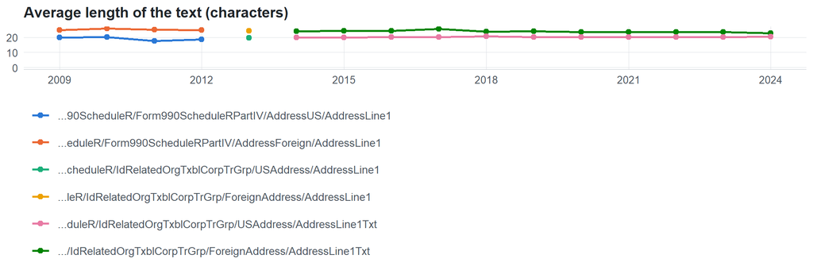

**Table view**

Table view: length and variety by tax year

| Series | Tax year | Filings | Avg length | Max length | Distinct values (approx.) |
| --- | --- | --- | --- | --- | --- |
| …90ScheduleR/Form990ScheduleRPartIV/AddressUS/AddressLine1 | 2009 | 4,167 | 20 | 35 | 3,186 |
| …90ScheduleR/Form990ScheduleRPartIV/AddressUS/AddressLine1 | 2010 | 10,720 | 20 | 35 | 3,859 |
| …90ScheduleR/Form990ScheduleRPartIV/AddressUS/AddressLine1 | 2011 | 12,659 | 17 | 35 | 23,794 |
| …90ScheduleR/Form990ScheduleRPartIV/AddressUS/AddressLine1 | 2012 | 13,398 | 19 | 35 | 16,756 |
| …eduleR/Form990ScheduleRPartIV/AddressForeign/AddressLine1 | 2009 | 592 | 25 | 35 | 373 |
| …eduleR/Form990ScheduleRPartIV/AddressForeign/AddressLine1 | 2010 | 1,363 | 26 | 35 | 563 |
| …eduleR/Form990ScheduleRPartIV/AddressForeign/AddressLine1 | 2011 | 1,690 | 25 | 35 | 710 |
| …eduleR/Form990ScheduleRPartIV/AddressForeign/AddressLine1 | 2012 | 1,868 | 25 | 35 | 890 |
| …cheduleR/IdRelatedOrgTxblCorpTrGrp/USAddress/AddressLine1 | 2013 | 14,114 | 20 | 35 | 8,375 |
| …leR/IdRelatedOrgTxblCorpTrGrp/ForeignAddress/AddressLine1 | 2013 | 2,008 | 24 | 35 | 698 |
| …duleR/IdRelatedOrgTxblCorpTrGrp/USAddress/AddressLine1Txt | 2014 | 14,930 | 20 | 35 | 12,692 |
| …duleR/IdRelatedOrgTxblCorpTrGrp/USAddress/AddressLine1Txt | 2015 | 15,444 | 20 | 35 | 13,659 |
| …duleR/IdRelatedOrgTxblCorpTrGrp/USAddress/AddressLine1Txt | 2016 | 15,775 | 20 | 35 | 17,889 |
| …duleR/IdRelatedOrgTxblCorpTrGrp/USAddress/AddressLine1Txt | 2017 | 16,561 | 20 | 35 | 13,263 |
| …duleR/IdRelatedOrgTxblCorpTrGrp/USAddress/AddressLine1Txt | 2018 | 16,741 | 21 | 35 | 14,599 |
| …duleR/IdRelatedOrgTxblCorpTrGrp/USAddress/AddressLine1Txt | 2019 | 17,305 | 20 | 35 | 9,231 |
| …duleR/IdRelatedOrgTxblCorpTrGrp/USAddress/AddressLine1Txt | 2020 | 18,341 | 20 | 35 | 9,158 |
| …duleR/IdRelatedOrgTxblCorpTrGrp/USAddress/AddressLine1Txt | 2021 | 18,550 | 20 | 35 | 15,666 |
| …duleR/IdRelatedOrgTxblCorpTrGrp/USAddress/AddressLine1Txt | 2022 | 18,640 | 20 | 35 | 24,536 |
| …duleR/IdRelatedOrgTxblCorpTrGrp/USAddress/AddressLine1Txt | 2023 | 18,431 | 20 | 35 | 10,417 |
| …duleR/IdRelatedOrgTxblCorpTrGrp/USAddress/AddressLine1Txt | 2024 | 11,625 | 20 | 35 | 8,043 |
| …/IdRelatedOrgTxblCorpTrGrp/ForeignAddress/AddressLine1Txt | 2014 | 2,055 | 24 | 35 | 795 |
| …/IdRelatedOrgTxblCorpTrGrp/ForeignAddress/AddressLine1Txt | 2015 | 2,200 | 24 | 35 | 902 |
| …/IdRelatedOrgTxblCorpTrGrp/ForeignAddress/AddressLine1Txt | 2016 | 2,315 | 24 | 35 | 1,093 |
| …/IdRelatedOrgTxblCorpTrGrp/ForeignAddress/AddressLine1Txt | 2017 | 2,410 | 26 | 35 | 1,393 |
| …/IdRelatedOrgTxblCorpTrGrp/ForeignAddress/AddressLine1Txt | 2018 | 2,734 | 24 | 35 | 1,076 |
| …/IdRelatedOrgTxblCorpTrGrp/ForeignAddress/AddressLine1Txt | 2019 | 2,895 | 24 | 35 | 1,266 |
| …/IdRelatedOrgTxblCorpTrGrp/ForeignAddress/AddressLine1Txt | 2020 | 3,032 | 23 | 35 | 1,372 |
| …/IdRelatedOrgTxblCorpTrGrp/ForeignAddress/AddressLine1Txt | 2021 | 3,114 | 23 | 35 | 1,324 |
| …/IdRelatedOrgTxblCorpTrGrp/ForeignAddress/AddressLine1Txt | 2022 | 3,131 | 23 | 35 | 1,729 |
| …/IdRelatedOrgTxblCorpTrGrp/ForeignAddress/AddressLine1Txt | 2023 | 3,102 | 23 | 35 | 1,359 |
| …/IdRelatedOrgTxblCorpTrGrp/ForeignAddress/AddressLine1Txt | 2024 | 1,451 | 23 | 35 | 1,061 |

Most common values by xpath (all years; long values truncated)

| Series | Value | Filings | Share |
| --- | --- | --- | --- |
| …90ScheduleR/Form990ScheduleRPartIV/AddressUS/AddressLine1 | 1330 BLAKELY CIRCLE SW | 564 | 1.4% |
| …90ScheduleR/Form990ScheduleRPartIV/AddressUS/AddressLine1 | 300 OVERSTREET WAY | 564 | 1.4% |
| …90ScheduleR/Form990ScheduleRPartIV/AddressUS/AddressLine1 | 3503 CAMINO REAL | 564 | 1.4% |
| …90ScheduleR/Form990ScheduleRPartIV/AddressUS/AddressLine1 | 3630 MOORES TRAIL RD | 564 | 1.4% |
| …90ScheduleR/Form990ScheduleRPartIV/AddressUS/AddressLine1 | 382 WOODRIDGE DR | 564 | 1.4% |
| …90ScheduleR/Form990ScheduleRPartIV/AddressUS/AddressLine1 | 6003 ABBEY CHAPEL DR | 564 | 1.4% |
| …90ScheduleR/Form990ScheduleRPartIV/AddressUS/AddressLine1 | 16400 DIX-TOLEDO HWY | 378 | 0.9% |
| …90ScheduleR/Form990ScheduleRPartIV/AddressUS/AddressLine1 | 3400 VISION CENTER COURT | 375 | 0.9% |
| …90ScheduleR/Form990ScheduleRPartIV/AddressUS/AddressLine1 | 5656 FARMHOUSE LANE | 375 | 0.9% |
| …90ScheduleR/Form990ScheduleRPartIV/AddressUS/AddressLine1 | 630 SOUTH SUNBURY RD | 375 | 0.9% |
| …90ScheduleR/Form990ScheduleRPartIV/AddressUS/AddressLine1 | 6900 HARVARD AVE | 375 | 0.9% |
| …90ScheduleR/Form990ScheduleRPartIV/AddressUS/AddressLine1 | 711 N EUCLID AVE | 189 | 0.5% |
| …90ScheduleR/Form990ScheduleRPartIV/AddressUS/AddressLine1 | 7210 WILLIAMS RD | 189 | 0.5% |
| …90ScheduleR/Form990ScheduleRPartIV/AddressUS/AddressLine1 | 76 St Paul Street Suite 500 | 103 | 0.3% |
| …90ScheduleR/Form990ScheduleRPartIV/AddressUS/AddressLine1 | 1111 6th Avenue | 100 | 0.2% |
| …90ScheduleR/Form990ScheduleRPartIV/AddressUS/AddressLine1 | 1149 Market St | 100 | 0.2% |
| …90ScheduleR/Form990ScheduleRPartIV/AddressUS/AddressLine1 | 1415 Southgate | 100 | 0.2% |
| …90ScheduleR/Form990ScheduleRPartIV/AddressUS/AddressLine1 | 1717 South J Street | 100 | 0.2% |
| …90ScheduleR/Form990ScheduleRPartIV/AddressUS/AddressLine1 | 2700 Stewart Parkway | 100 | 0.2% |
| …90ScheduleR/Form990ScheduleRPartIV/AddressUS/AddressLine1 | 2727 McClelland Blvd | 100 | 0.2% |
| …90ScheduleR/Form990ScheduleRPartIV/AddressUS/AddressLine1 | 3515 Broadway | 100 | 0.2% |
| …90ScheduleR/Form990ScheduleRPartIV/AddressUS/AddressLine1 | 6028 Shallowford Road Suite D | 100 | 0.2% |
| …90ScheduleR/Form990ScheduleRPartIV/AddressUS/AddressLine1 | 66 Ford Road | 100 | 0.2% |
| …eduleR/Form990ScheduleRPartIV/AddressForeign/AddressLine1 | PO Box 69 | 341 | 6.2% |
| …eduleR/Form990ScheduleRPartIV/AddressForeign/AddressLine1 | 11 Victoria Street | 336 | 6.1% |
| …eduleR/Form990ScheduleRPartIV/AddressForeign/AddressLine1 | PO BOX 10073 APO | 281 | 5.1% |
| …eduleR/Form990ScheduleRPartIV/AddressForeign/AddressLine1 | PO BOX 1051 GRAND CAYMAN | 260 | 4.7% |
| …eduleR/Form990ScheduleRPartIV/AddressForeign/AddressLine1 | PO BOX 1051 | 191 | 3.5% |
| …eduleR/Form990ScheduleRPartIV/AddressForeign/AddressLine1 | C/O AON Insurance Managers PO Box | 183 | 3.3% |
| …eduleR/Form990ScheduleRPartIV/AddressForeign/AddressLine1 | PO BOX 69 GT 720 WEST BAY ROAD | 120 | 2.2% |

First rows shown.

## Examples

| Tax year | Return | Xpath | Organization | Value | Source |
| --- | --- | --- | --- | --- | --- |
| 2024 | 990 | IRS990ScheduleR/IdRelatedOrgTxblCorpTrGrp/ForeignAddress/AddressLine1Txt | AVMED INC | PO BOX 1051 | [XML](https://gt990datalake-rawdata.s3.amazonaws.com/EfileData/XmlFiles/202533099349303308_public.xml) |
| 2024 | 990 | IRS990ScheduleR/IdRelatedOrgTxblCorpTrGrp/USAddress/AddressLine1Txt | RISEWELL COMMUNITY SERVICES INC FKA | 1 FARMINGDALE ROAD-ROUTE 109 | [XML](https://gt990datalake-rawdata.s3.amazonaws.com/EfileData/XmlFiles/202610589349301811_public.xml) |
| 2023 | 990 | IRS990ScheduleR/IdRelatedOrgTxblCorpTrGrp/ForeignAddress/AddressLine1Txt | GREATER GOOD CHARITIES | RONDO IGNACEGO DASZYNSKIEGO 2B | [XML](https://gt990datalake-rawdata.s3.amazonaws.com/EfileData/XmlFiles/202521359349316272_public.xml) |
| 2023 | 990 | IRS990ScheduleR/IdRelatedOrgTxblCorpTrGrp/USAddress/AddressLine1Txt | AK Steel Corp VEBA UAW Retirees | 9227 CENTRE POINT DRIVE | [XML](https://gt990datalake-rawdata.s3.amazonaws.com/EfileData/XmlFiles/202442269349300844_public.xml) |
| 2022 | 990 | IRS990ScheduleR/IdRelatedOrgTxblCorpTrGrp/ForeignAddress/AddressLine1Txt | Scott & White Healthcare | 23 Lime Tree Bay | [XML](https://gt990datalake-rawdata.s3.amazonaws.com/EfileData/XmlFiles/202441349349302274_public.xml) |
| 2022 | 990 | IRS990ScheduleR/IdRelatedOrgTxblCorpTrGrp/USAddress/AddressLine1Txt | Alexian Brothers - AHS Midwest Region Health Co | 200 S WACKER DRIVE | [XML](https://gt990datalake-rawdata.s3.amazonaws.com/EfileData/XmlFiles/202401369349308605_public.xml) |
| 2021 | 990 | IRS990ScheduleR/IdRelatedOrgTxblCorpTrGrp/ForeignAddress/AddressLine1Txt | LAKEVILLE SURGERY PC | C/O Cedar House 41 Cedar Ave | [XML](https://gt990datalake-rawdata.s3.amazonaws.com/EfileData/XmlFiles/202243189349301614_public.xml) |
| 2021 | 990 | IRS990ScheduleR/IdRelatedOrgTxblCorpTrGrp/USAddress/AddressLine1Txt | St John Providence | C/O TAX DEPARTMENT | [XML](https://gt990datalake-rawdata.s3.amazonaws.com/EfileData/XmlFiles/202311329349304191_public.xml) |
| 2020 | 990 | IRS990ScheduleR/IdRelatedOrgTxblCorpTrGrp/ForeignAddress/AddressLine1Txt | ST LUKE’S PROPERTIES CORPORATION | PO BOX 10073 APO | [XML](https://gt990datalake-rawdata.s3.amazonaws.com/EfileData/XmlFiles/202241369349302974_public.xml) |
| 2020 | 990 | IRS990ScheduleR/IdRelatedOrgTxblCorpTrGrp/USAddress/AddressLine1Txt | ORLANDO REGIONAL REALTOR ASSOCIATION | 1330 LEE ROAD | [XML](https://gt990datalake-rawdata.s3.amazonaws.com/EfileData/XmlFiles/202113199349304396_public.xml) |
| 2019 | 990 | IRS990ScheduleR/IdRelatedOrgTxblCorpTrGrp/ForeignAddress/AddressLine1Txt | MERCY MINISTRIES OF LAREDO | Aon House 30 Woodbourne Avenue | [XML](https://gt990datalake-rawdata.s3.amazonaws.com/EfileData/XmlFiles/202101319349300420_public.xml) |
| 2019 | 990 | IRS990ScheduleR/IdRelatedOrgTxblCorpTrGrp/USAddress/AddressLine1Txt | SOUTHFIELD NON-PROFIT HOUSING CORP | 19785 W 12 MILE RD | [XML](https://gt990datalake-rawdata.s3.amazonaws.com/EfileData/XmlFiles/202013169349303486_public.xml) |

## Reviewer checklist

- The definition matches the form line and instructions for every xpath’s schema years.
- Every xpath pooled here measures the same thing on the 990 and 990-EZ (close enough for analysis).
- The coverage chart has no unexplained gaps or jumps between tax years.
- Each open flag is fixed, or accepted with a note in validation_log.csv.
- Values answer the question on the form line (not another line’s explanation).
- Boilerplate such as ‘See Schedule O’ or ‘N/A’ is expected here, or should be treated as missing.
- Text that is really a number or a code is flagged for a different data type.

Record the review as a row in `inst/extdata/src/validation_log.csv` (variable_name, reviewer, date, status, note). Evidence built 2026-09-23 17:09:04 MST from the ef2 DuckDB builds (tax years 2009–2024).